# ExtraaLearn Project

## Context

The EdTech industry has been surging in the past decade immensely, and according to a forecast, the Online Education market would be worth $286.62bn by 2023 with a compound annual growth rate (CAGR) of 10.26% from 2018 to 2023. The modern era of online education has enforced a lot in its growth and expansion beyond any limit. Due to having many dominant features like ease of information sharing, personalized learning experience, transparency of assessment, etc, it is now preferable to traditional education.

In the present scenario due to the Covid-19, the online education sector has witnessed rapid growth and is attracting a lot of new customers. Due to this rapid growth, many new companies have emerged in this industry. With the availability and ease of use of digital marketing resources, companies can reach out to a wider audience with their offerings. The customers who show interest in these offerings are termed as leads. There are various sources of obtaining leads for Edtech companies, like

- The customer interacts with the marketing front on social media or other online platforms.
- The customer browses the website/app and downloads the brochure
- The customer connects through emails for more information.

The company then nurtures these leads and tries to convert them to paid customers. For this, the representative from the organization connects with the lead on call or through email to share further details.

## Objective

ExtraaLearn is an initial stage startup that offers programs on cutting-edge technologies to students and professionals to help them upskill/reskill. With a large number of leads being generated on a regular basis, one of the issues faced by ExtraaLearn is to identify which of the leads are more likely to convert so that they can allocate resources accordingly. You, as a data scientist at ExtraaLearn, have been provided the leads data to:

- Analyze and build an ML model to help identify which leads are more likely to convert to paid customers,
- Find the factors driving the lead conversion process
- Create a profile of the leads which are likely to convert

## Data Description

The data contains the different attributes of leads and their interaction details with ExtraaLearn. The detailed data dictionary is given below.

**Data Dictionary**

- ID: ID of the lead
- age: Age of the lead
- current_occupation: Current occupation of the lead. Values include 'Professional','Unemployed',and 'Student'
- first_interaction: How did the lead first interacted with ExtraaLearn. Values include 'Website', 'Mobile App'
- profile_completed: What percentage of profile has been filled by the lead on the website/mobile app. Values include Low - (0-50%), Medium - (50-75%), High (75-100%)
- website_visits: How many times has a lead visited the website
- time_spent_on_website: Total time spent on the website
- page_views_per_visit: Average number of pages on the website viewed during the visits.
- last_activity: Last interaction between the lead and ExtraaLearn.
  - Email Activity: Seeking for details about program through email, Representative shared information with lead like brochure of program , etc
  - Phone Activity: Had a Phone Conversation with representative, Had conversation over SMS with representative, etc
  - Website Activity: Interacted on live chat with representative, Updated profile on website, etc
- print_media_type1: Flag indicating whether the lead had seen the ad of ExtraaLearn in the Newspaper.
- print_media_type2: Flag indicating whether the lead had seen the ad of ExtraaLearn in the Magazine.
- digital_media: Flag indicating whether the lead had seen the ad of ExtraaLearn on the digital platforms.
- educational_channels: Flag indicating whether the lead had heard about ExtraaLearn in the education channels like online forums, discussion threads, educational websites, etc.
- referral: Flag indicating whether the lead had heard about ExtraaLearn through reference.
- status: Flag indicating whether the lead was converted to a paid customer or not.

## Importing necessary libraries and data

```python
# Importing the basic libraries we will require for the project

# Libraries to help with reading and manipulating data
import pandas as pd
import numpy as np

# Libaries to help with data visualization
import matplotlib.pyplot as plt
import seaborn as sns
sns.set()

# Importing the Machine Learning models we require from Scikit-Learn
from sklearn.linear_model import LogisticRegression
from sklearn.svm import SVC
from sklearn.tree import DecisionTreeClassifier
from sklearn import tree
from sklearn.ensemble import RandomForestClassifier

# Importing the other functions we may require from Scikit-Learn
from sklearn.model_selection import train_test_split, GridSearchCV
from sklearn.preprocessing import MinMaxScaler, LabelEncoder, OneHotEncoder
from sklearn.impute import SimpleImputer

# To get diferent metric scores
from sklearn.metrics import confusion_matrix,classification_report,roc_auc_score,precision_recall_curve,roc_curve,make_scorer

# Code to ignore warnings from function usage
import warnings;
import numpy as np
warnings.filterwarnings('ignore')
```

```python
df = pd.read_csv('/content/ExtraaLearn (2).csv')
```

## Data Overview

- Observations
- Sanity checks

```python
df.shape
```

```
(4612, 15)
```

```python
df.info()
```

```
<class 'pandas.core.frame.DataFrame'>
RangeIndex: 4612 entries, 0 to 4611
Data columns (total 15 columns):
 #   Column                 Non-Null Count  Dtype
---  ------                 --------------  -----
 0   ID                     4612 non-null   object
 1   age                    4612 non-null   int64
 2   current_occupation     4612 non-null   object
 3   first_interaction      4612 non-null   object
 4   profile_completed      4612 non-null   object
 5   website_visits         4612 non-null   int64
 6   time_spent_on_website  4612 non-null   int64
 7   page_views_per_visit   4612 non-null   float64
 8   last_activity          4612 non-null   object
 9   print_media_type1      4612 non-null   object
 10  print_media_type2      4612 non-null   object
 11  digital_media          4612 non-null   object
 12  educational_channels   4612 non-null   object
 13  referral               4612 non-null   object
 14  status                 4612 non-null   int64
dtypes: float64(1), int64(4), object(10)
memory usage: 540.6+ KB
```

```python
df.describe().T
```

|  | count | mean | std | min | 25% | 50% | 75% | max |
| --- | --- | --- | --- | --- | --- | --- | --- | --- |
| age | 4612.0 | 46.201214 | 13.161454 | 18.0 | 36.00000 | 51.000 | 57.00000 | 63.000 |
| website_visits | 4612.0 | 3.566782 | 2.829134 | 0.0 | 2.00000 | 3.000 | 5.00000 | 30.000 |
| time_spent_on_website | 4612.0 | 724.011275 | 743.828683 | 0.0 | 148.75000 | 376.000 | 1336.75000 | 2537.000 |
| page_views_per_visit | 4612.0 | 3.026126 | 1.968125 | 0.0 | 2.07775 | 2.792 | 3.75625 | 18.434 |
| status | 4612.0 | 0.298569 | 0.457680 | 0.0 | 0.00000 | 0.000 | 1.00000 | 1.000 |

```python
df.duplicated().sum()
```

```
np.int64(0)
```

```python
df.isnull().sum()
```

|  | 0 |
| --- | --- |
| ID | 0 |
| age | 0 |
| current_occupation | 0 |
| first_interaction | 0 |
| profile_completed | 0 |
| website_visits | 0 |
| time_spent_on_website | 0 |
| page_views_per_visit | 0 |
| last_activity | 0 |
| print_media_type1 | 0 |
| print_media_type2 | 0 |
| digital_media | 0 |
| educational_channels | 0 |
| referral | 0 |
| status | 0 |

**dtype:** int64

## Exploratory Data Analysis (EDA)

- EDA is an important part of any project involving data.
- It is important to investigate and understand the data better before building a model with it.
- A few questions have been mentioned below which will help you approach the analysis in the right manner and generate insights from the data.
- A thorough analysis of the data, in addition to the questions mentioned below, should be done.

**Questions**

1. Leads will have different expectations from the outcome of the course and the current occupation may play a key role in getting them to participate in the program. Find out how current occupation affects lead status.
2. The company's first impression on the customer must have an impact. Do the first channels of interaction have an impact on the lead status?
3. The company uses multiple modes to interact with prospects. Which way of interaction works best?
4. The company gets leads from various channels such as print media, digital media, referrals, etc. Which of these channels have the highest lead conversion rate?
5. People browsing the website or mobile application are generally required to create a profile by sharing their personal data before they can access additional information.Does having more details about a prospect increase the chances of conversion?

## Data Preprocessing

- Missing value treatment (if needed)
- Feature engineering (if needed)
- Outlier detection and treatment (if needed)
- Preparing data for modeling
- Any other preprocessing steps (if needed)

```python
num_cols = df.select_dtypes(include=np.number).columns.tolist()
cat_cols = [c for c in df.columns if c not in num_cols]
```

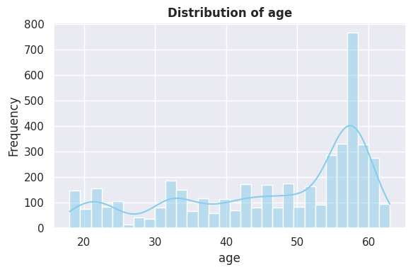

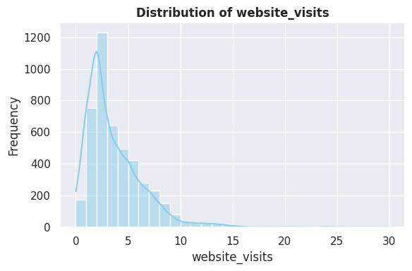

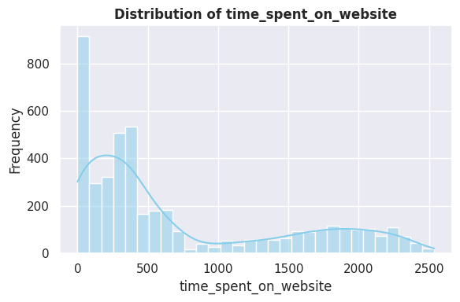

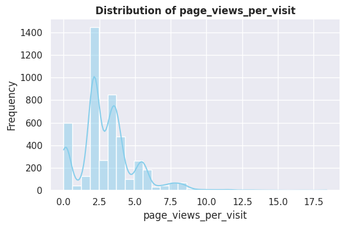

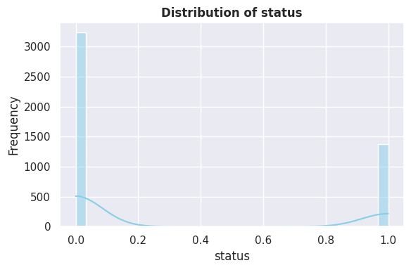

```python
for col in num_cols:
    plt.figure(figsize=(6,4))
    sns.histplot(df[col], bins=30, kde=True, color='skyblue')
    plt.title(f"Distribution of {col}", fontsize=12, fontweight='bold')
    plt.xlabel(col)
    plt.ylabel('Frequency')
    plt.tight_layout()
    plt.show()
```

[figure not shown]

```
Value counts for ID:
 ID
EXT4612    0.0
EXT001     0.0
EXT002     0.0
EXT003     0.0
EXT4596    0.0
          ...
EXT009     0.0
EXT008     0.0
EXT007     0.0
EXT006     0.0
EXT005     0.0
Name: proportion, Length: 4612, dtype: float64
```

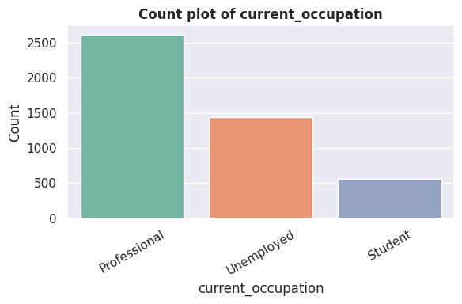

```
Value counts for current_occupation:
 current_occupation
Professional    56.7
Unemployed      31.2
Student         12.0
Name: proportion, dtype: float64
```

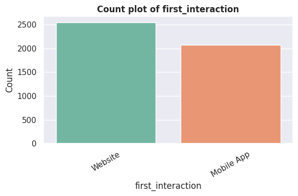

```
Value counts for first_interaction:
 first_interaction
Website       55.1
Mobile App    44.9
Name: proportion, dtype: float64
```

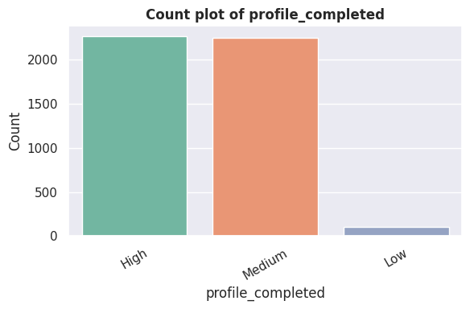

```
Value counts for profile_completed:
 profile_completed
High      49.1
Medium    48.6
Low        2.3
Name: proportion, dtype: float64
```

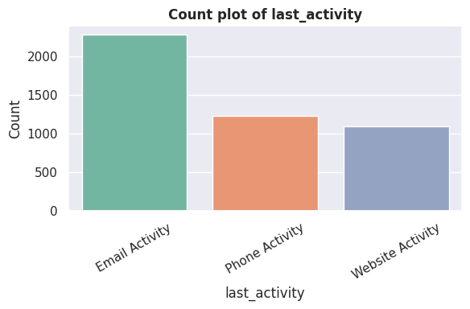

```
Value counts for last_activity:
 last_activity
Email Activity      49.4
Phone Activity      26.8
Website Activity    23.9
Name: proportion, dtype: float64
```

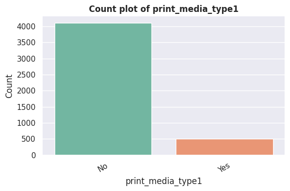

```
Value counts for print_media_type1:
 print_media_type1
No     89.2
Yes    10.8
Name: proportion, dtype: float64
```

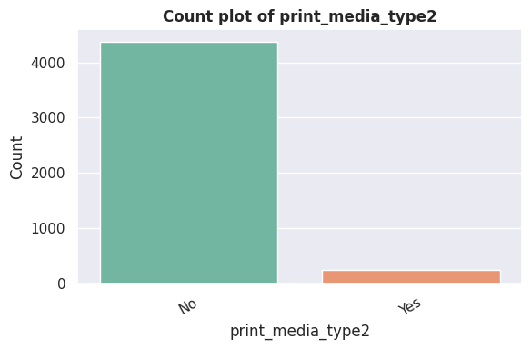

```
Value counts for print_media_type2:
 print_media_type2
No     94.9
Yes     5.1
Name: proportion, dtype: float64
```

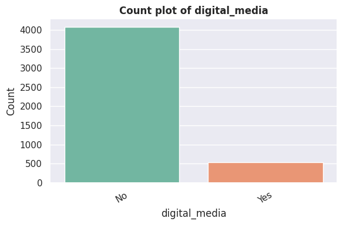

```
Value counts for digital_media:
 digital_media
No     88.6
Yes    11.4
Name: proportion, dtype: float64
```

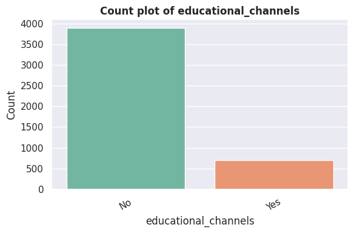

```
Value counts for educational_channels:
 educational_channels
No     84.7
Yes    15.3
Name: proportion, dtype: float64
```

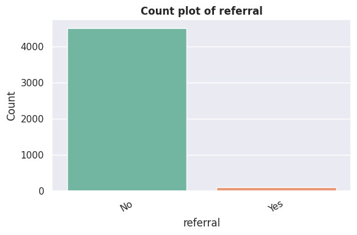

```
Value counts for referral:
 referral
No     98.0
Yes     2.0
Name: proportion, dtype: float64
```

```python
for col in cat_cols:
    plt.figure(figsize=(6,4))
    order = df[col].value_counts().index
    sns.countplot(data=df, x=col, order=order, palette='Set2')
    plt.title(f"Count plot of {col}", fontsize=12, fontweight='bold')
    plt.xticks(rotation=30)
    plt.ylabel("Count")
    plt.tight_layout()
    plt.show()
    print(f"\nValue counts for {col}:\n", df[col].value_counts(normalize=True).round(3)*100)
```

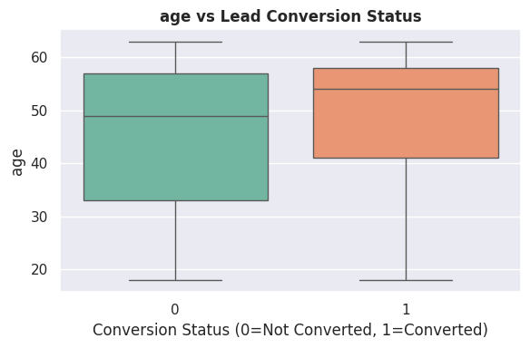

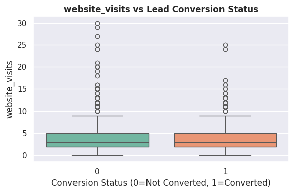

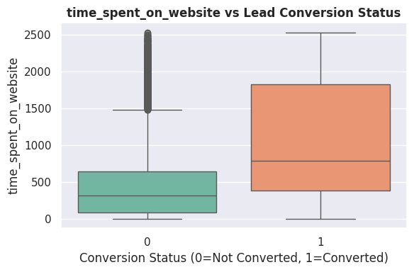

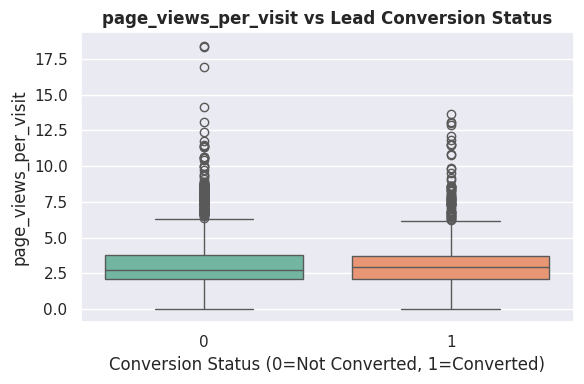

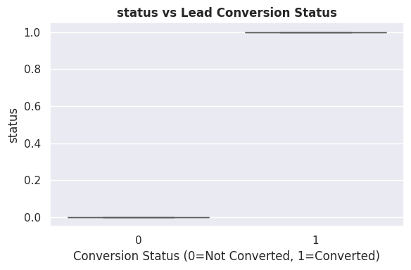

```python
for col in num_cols:
    plt.figure(figsize=(6,4))
    sns.boxplot(data=df, x='status', y=col, palette='Set2')
    plt.title(f"{col} vs Lead Conversion Status", fontsize=12, fontweight='bold')
    plt.xlabel("Conversion Status (0=Not Converted, 1=Converted)")
    plt.ylabel(col)
    plt.tight_layout()
    plt.show()
```

[figure not shown]

```
Conversion Rate (%) by ID:
 ID
EXT001    100.0
EXT002      0.0
EXT003      0.0
EXT004    100.0
EXT005      0.0
          ...
EXT995      0.0
EXT996      0.0
EXT997    100.0
EXT998      0.0
EXT999      0.0
Name: status, Length: 4612, dtype: float64
```

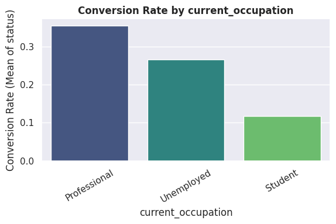

```
Conversion Rate (%) by current_occupation:
 current_occupation
Professional    35.51
Student         11.71
Unemployed      26.58
Name: status, dtype: float64
```

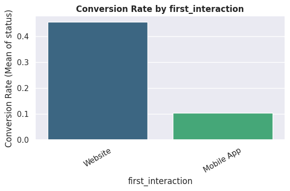

```
Conversion Rate (%) by first_interaction:
 first_interaction
Mobile App    10.53
Website       45.59
Name: status, dtype: float64
```

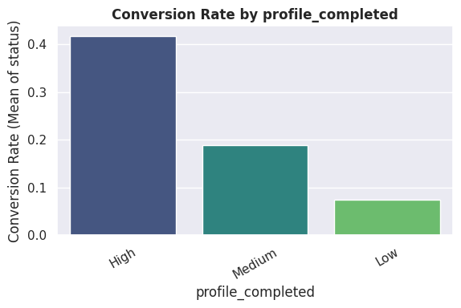

```
Conversion Rate (%) by profile_completed:
 profile_completed
High      41.78
Low        7.48
Medium    18.88
Name: status, dtype: float64
```

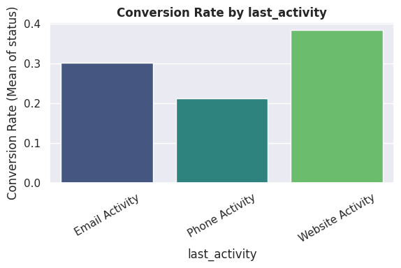

```
Conversion Rate (%) by last_activity:
 last_activity
Email Activity      30.33
Phone Activity      21.31
Website Activity    38.45
Name: status, dtype: float64
```

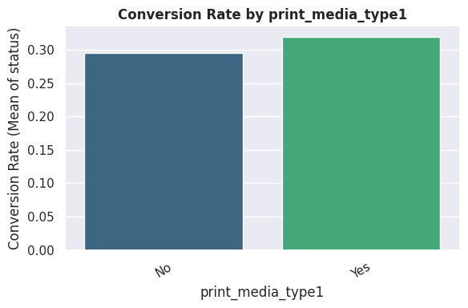

```
Conversion Rate (%) by print_media_type1:
 print_media_type1
No     29.60
Yes    31.99
Name: status, dtype: float64
```

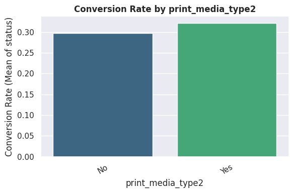

```
Conversion Rate (%) by print_media_type2:
 print_media_type2
No     29.73
Yes    32.19
Name: status, dtype: float64
```

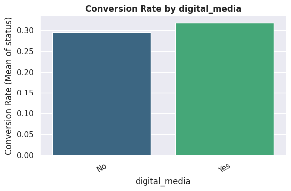

```
Conversion Rate (%) by digital_media:
 digital_media
No     29.60
Yes    31.88
Name: status, dtype: float64
```

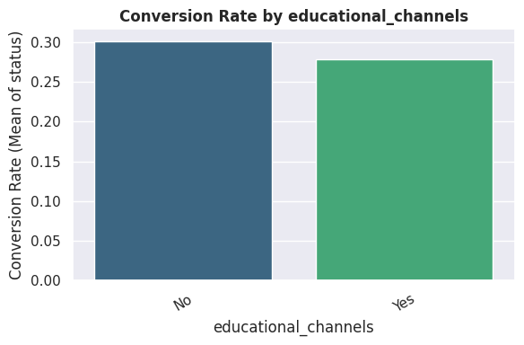

```
Conversion Rate (%) by educational_channels:
 educational_channels
No     30.20
Yes    27.94
Name: status, dtype: float64
```

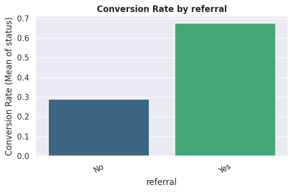

```
Conversion Rate (%) by referral:
 referral
No     29.08
Yes    67.74
Name: status, dtype: float64
```

```python
for col in cat_cols:
    plt.figure(figsize=(6,4))
    order = df[col].value_counts().index
    sns.barplot(data=df, x=col, y='status', order=order, palette='viridis', ci=None)
    plt.title(f"Conversion Rate by {col}", fontsize=12, fontweight='bold')
    plt.xlabel(col)
    plt.ylabel("Conversion Rate (Mean of status)")
    plt.xticks(rotation=30)
    plt.tight_layout()
    plt.show()

    # Print conversion rates
    rates = (df.groupby(col)['status'].mean()*100).round(2)
    print(f"Conversion Rate (%) by {col}:\n", rates, "\n")
```

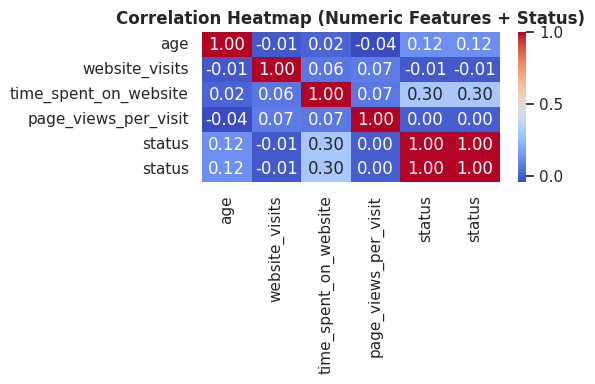

```python
plt.figure(figsize=(6,4))
sns.heatmap(df[num_cols + ['status']].corr(), annot=True, cmap='coolwarm', fmt=".2f")
plt.title("Correlation Heatmap (Numeric Features + Status)", fontsize=12, fontweight='bold')
plt.tight_layout()
plt.show()
```

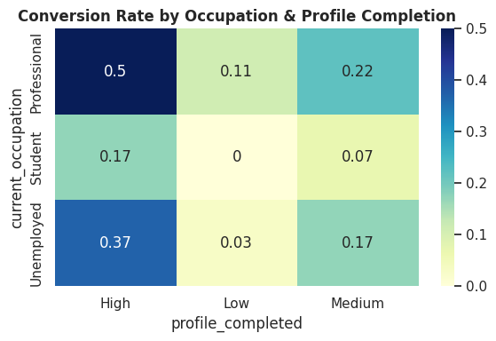

```
Conversion matrix:
 profile_completed   High   Low  Medium
current_occupation
Professional        0.50  0.11    0.22
Student             0.17  0.00    0.07
Unemployed          0.37  0.03    0.17
```

```python
if 'current_occupation' in df.columns and 'profile_completed' in df.columns:
    pivot = df.pivot_table(values='status',
                           index='current_occupation',
                           columns='profile_completed',
                           aggfunc='mean').round(2)
    plt.figure(figsize=(6,4))
    sns.heatmap(pivot, annot=True, cmap='YlGnBu')
    plt.title("Conversion Rate by Occupation & Profile Completion", fontsize=12, fontweight='bold')
    plt.tight_layout()
    plt.show()
    print("\nConversion matrix:\n", pivot)
```

```python
# -----------------------------
# 1️⃣ Drop unnecessary or ID columns
# -----------------------------
# 'ID' is a unique identifier, not useful for prediction
if "ID" in df.columns:
    df.drop(columns=["ID"], inplace=True)

# -----------------------------
# 2️⃣ Check for high-missing or constant columns
# -----------------------------
missing_ratio = df.isnull().mean().round(3)
constant_cols = [c for c in df.columns if df[c].nunique() <= 1]
high_missing = missing_ratio[missing_ratio > 0.4].index.tolist()  # >40% missing

print("Columns with high missing values:", high_missing)
print("Constant columns:", constant_cols)

df.drop(columns=constant_cols + high_missing, inplace=True, errors="ignore")

# -----------------------------
# 3️⃣ Handle categorical encodings
# -----------------------------
# Standardize text casing and strip spaces
cat_cols = df.select_dtypes(include="object").columns.tolist()
for c in cat_cols:
    df[c] = df[c].astype(str).str.strip().str.title()

# -----------------------------
# 4️⃣ Create new engineered features
# -----------------------------

# Profile completion as ordered numeric levels
profile_map = {"Low": 1, "Medium": 2, "High": 3}
if "profile_completed" in df.columns:
    df["profile_level"] = df["profile_completed"].map(profile_map)

# Engagement score = website_visits * page_views_per_visit * (time_spent_on_website / 100)
if set(["website_visits", "page_views_per_visit", "time_spent_on_website"]).issubset(df.columns):
    df["engagement_score"] = (
        df["website_visits"] * df["page_views_per_visit"] * (df["time_spent_on_website"] / 100)
    ).round(2)

# Age group bucket
if "age" in df.columns:
    df["age_group"] = pd.cut(
        df["age"],
        bins=[0, 25, 35, 45, 55, 65],
        labels=["<25", "25-35", "35-45", "45-55", "55+"],
        include_lowest=True
    )

# Last activity bucket (Email, Phone, Website, Other)
def map_activity(x):
    if pd.isna(x):
        return "Unknown"
    x = str(x).lower()
    if "email" in x:
        return "Email"
    elif "phone" in x or "call" in x or "sms" in x:
        return "Phone"
    elif "web" in x or "site" in x or "chat" in x or "profile" in x:
        return "Website"
    else:
        return "Other"

if "last_activity" in df.columns:
    df["activity_type"] = df["last_activity"].map(map_activity)

# -----------------------------
# 5️⃣ Remove redundant columns post feature creation
# -----------------------------
drop_cols = ["last_activity"]  # already captured as activity_type
df.drop(columns=drop_cols, inplace=True, errors="ignore")

# -----------------------------
# 6️⃣ Handle missing values (simple imputation)
# -----------------------------
# Numeric → median; categorical → mode
num_cols = df.select_dtypes(include=[np.number]).columns
cat_cols = df.select_dtypes(exclude=[np.number]).columns

for col in num_cols:
    df[col] = df[col].fillna(df[col].median())

for col in cat_cols:
    df[col] = df[col].fillna(df[col].mode()[0])
```

```
Columns with high missing values: []
Constant columns: []
```

```python
df.head()
```

|  | age | current_occupation | first_interaction | profile_completed | website_visits | time_spent_on_website | page_views_per_visit | print_media_type1 | print_media_type2 | digital_media | educational_channels | referral | status | profile_level | engagement_score | age_group | activity_type |
| --- | --- | --- | --- | --- | --- | --- | --- | --- | --- | --- | --- | --- | --- | --- | --- | --- | --- |
| 0 | 57 | Unemployed | Website | High | 7 | 1639 | 1.861 | Yes | No | Yes | No | No | 1 | 3 | 213.51 | 55+ | Website |
| 1 | 56 | Professional | Mobile App | Medium | 2 | 83 | 0.320 | No | No | No | Yes | No | 0 | 2 | 0.53 | 55+ | Website |
| 2 | 52 | Professional | Website | Medium | 3 | 330 | 0.074 | No | No | Yes | No | No | 0 | 2 | 0.73 | 45-55 | Website |
| 3 | 53 | Unemployed | Website | High | 4 | 464 | 2.057 | No | No | No | No | No | 1 | 3 | 38.18 | 45-55 | Website |
| 4 | 23 | Student | Website | High | 4 | 600 | 16.914 | No | No | No | No | No | 0 | 3 | 405.94 | <25 | Email |